# Inferring comparison classes through pragmatic reasoning

Michael Lopez-Brau

# Introduction

Suppose you walk into a coffee shop and overhear someone say “the coffee is warm.” What do you think they meant by that? If the person is drinking a [cappuccino](https://en.wikipedia.org/wiki/Cappuccino), warm might mean around 60°C or 160°F. In contrast, if the person is drinking an [iced coffee](https://en.wikipedia.org/wiki/Iced_coffee), warm might mean around 15°C or 59°F. It is apparent that in order for us to ground a quantitative interpretation of the gradable adjective “warm,” we will need to find the set of similar entities that compare with the type of coffee in this utterance: we need to find the comparison class.

The question of what “warm” means directly and how to infer its meaning, as well as many other *gradable adjectives*, is an active area of research. There are two types of gradable adjectives: relative and absolute. In our work, we focus on relative gradable adjectives (e.g., tall, heavy, hot) because of their vagueness and context-sensitivity. We also focus on measurable adjectives for modeling simplicity. This allows us to study how the comparison class varies with respect to context while keeping the utterance fixed; thus, we obtain more flexibility in trying to elicit the comparison class in our experiments.

## What are comparison classes?

In Bale (2011), **comparison classes** are described as the implicitly or textually determined sets that relativize the standard for some gradable adjective. In our previous example, the comparison class would have been either $C$, the set of all cappuccinos, or $I$, the set of all iced coffees. A standard for “warm” could then be obtained by performing some operation on the scale associated with either of these sets, such as calculating the mean temperature over the set of cappuccinos. Note here that the standard is indeed relativized for “warm” because the mean temperature over $C$ would differ significantly from the mean temperature over $I$. Here, we see that several steps are required to infer a quantitative interpretation of “warm”:

1. Construct a scale for the gradable adjective (not necessarily equal to $\mathbb{R}$)
2. Compute or otherwise obtain a standard for the gradable adjective by performing some operation on the scale
3. Use a measure function $\mu$ to map the kind, or the subject of the utterance, to a value on the scale
4. Determine the truth value of the proposition given the interpretation (i.e. the value obtained from the scale)

Some notations and definitions that underlie the theory of comparison classes will be described as we discuss these steps. Though we are interested in determining the **scale** of a particular gradable adjective, it is not always so direct. We often have to start with and derive the scale from what is known as a **quasi-order**, a binary relation on a particular set. Without any context or restriction, this is a relation on the set $\mathbb{U}$, known in discrete mathematics as the *universe of discourse* (i.e. the set of all things). This relation has the properties of reflexivity and transitivity (see [here](http://www.inf.ed.ac.uk/teaching/courses/dmmr/slides/13-14/Ch2.pdf) for a more detailed discussion on relations in set theory). Figure 1 is an example of a quasi-order formed from the gradable adjective “warm”:

$\text{WARM}$

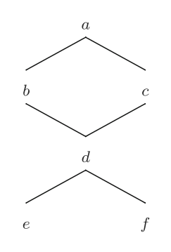

Figure 1: A graph describing the quasi-order for the relative gradable adjective “warm” with members from an unrestricted set.

The relation that corresponds to this graph is shown below:

$$\begin{equation}
\text{WARM} = \{(x, y) : x \text{ is (at least) as warm as } y\}
\end{equation}$$

What prevents quasi-orders from becoming scales is that they are not antisymmetric. This means that two cups of cappuccino (take $b$ and $c$ from the graph) with the same temperature will exist separately instead of being binned into the same category. For the sake of creating a one-to-one, kind-to-value measure function, we would like to bin these two cups of cappuccino into the same category. Fortunately, we can convert quasi-orders into scales by collapsing “equivalent” kinds into an *equivalence class*, forming what Bale (2011) calls *quotient structures*. The details of equivalence classes and quotient structures are outside of the scope of this work. They can simply be thought of as bins of entities with equal representations, such as temperature, and as scales, respectively. Taking the quasi-order from before, we can convert it to the scale in Figure 2.

$\text{WARM}$

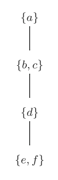

Figure 2: A graph describing a scale for the relative gradable adjective “warm” with similar members from an unrestricted set collapsed into an equivalence class.

# Framework

# Experiment

The pilot experiment was run on Amazon Mechanical Turk (MTurk) with 30 participants. Each participant had to answer 18 questions in a fill-in-the-blank and paraphrase format. The experiment took about five minutes and participants were paid $0.60. You can find the experiment [here](https://mhtess.github.io/comparison-class/).

Here is what a typical experiment trial would look like:

> Bill is a goat. John says, “Bill is tall.” What do you think John meant? “Bill is tall for a `goat`.”

In addition, each participant was randomly assigned a condition that changed the way the final line was phrased. The two conditions were “for a” and “relative to.” Given the fact that responses like “Drink” and “drink” might be miscategorized in separate bins, we compare responses that were parsed by hand with the caveman parser. In the next section, we graph the results of peoples’ responses and finish with a brief analysis and discussion in the section thereafter.

# Results

In the graphs below, the names of some of the bins were cut down due to space limitations. The full respones can be read from [here](https://github.com/lopez-brau/comparison-class/blob/master/data/pilot-1-paraphrase/pilot-1-paraphrase-pairs.csv).

## “for a” Condition

Target: “The coffee is hot.”

Context A: “X is a regular at the coffee shop and buys a cup of coffee.”

Context B: “X takes a sip of their friend’s coffee before returning back to their tea.”

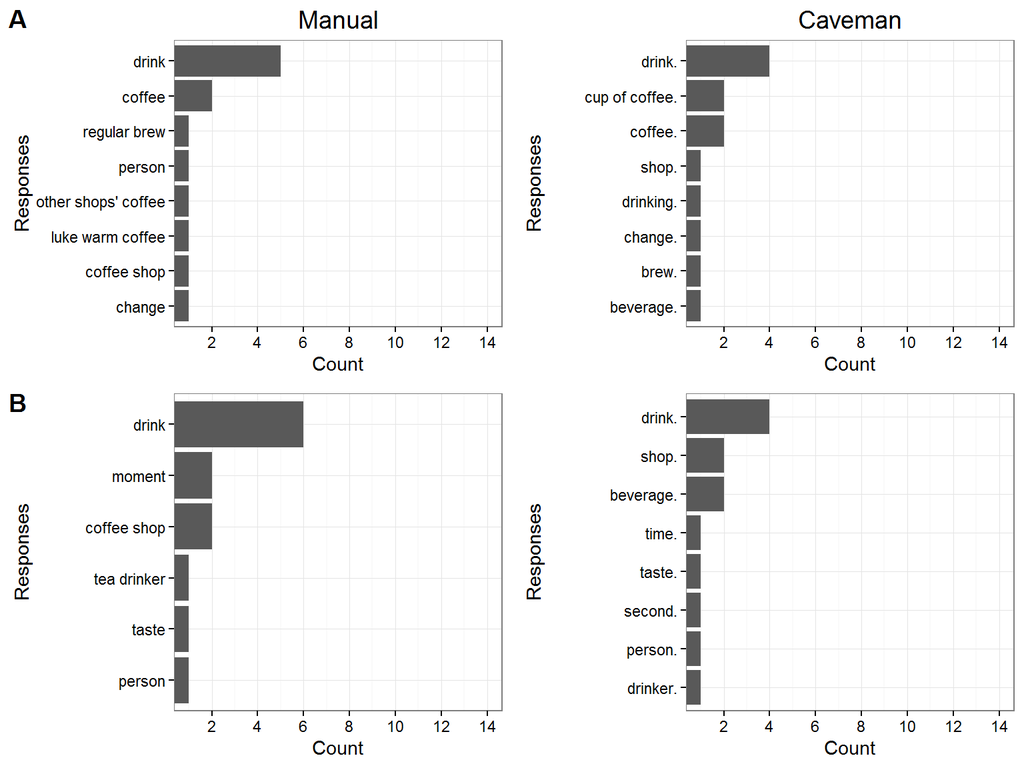

Target: “The weather is cold.”

Context A: “X just flew into New York from Florida.”

Context B: “X was raised in Russia.”

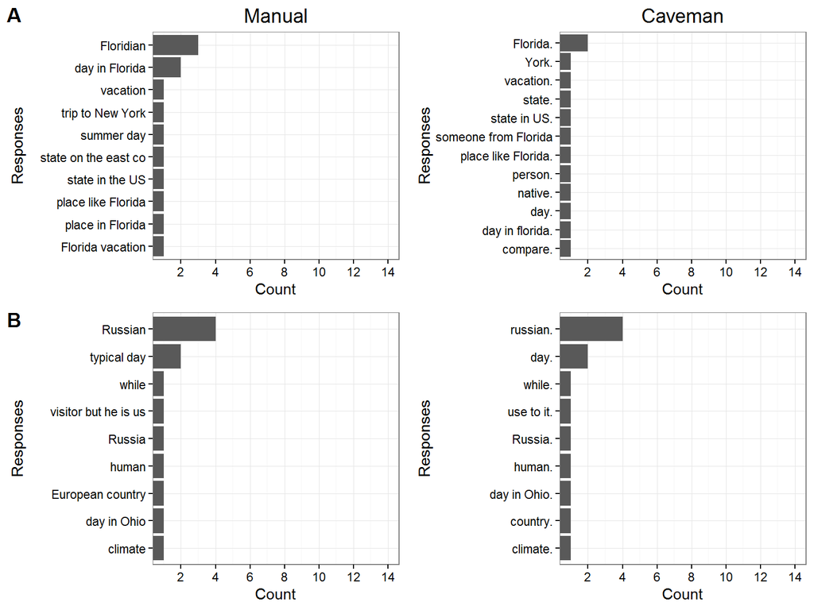

Target: “The necklace is expensive.”

Context A: “X is browsing at a jewelry store and stops to look at a necklace.”

Context B: " Xis buying a diamond necklace."

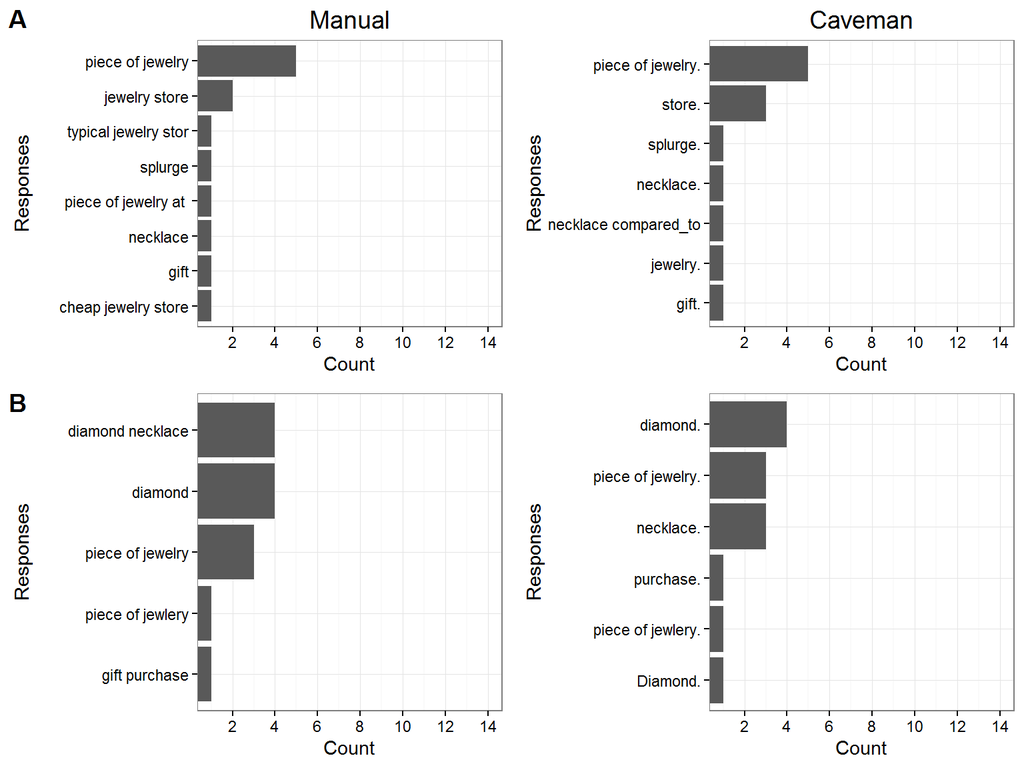

Target: “The ticket is cheap.”

Context A: “X is buying a movie ticket.”

Context B: “X got pulled over by a police officer.”

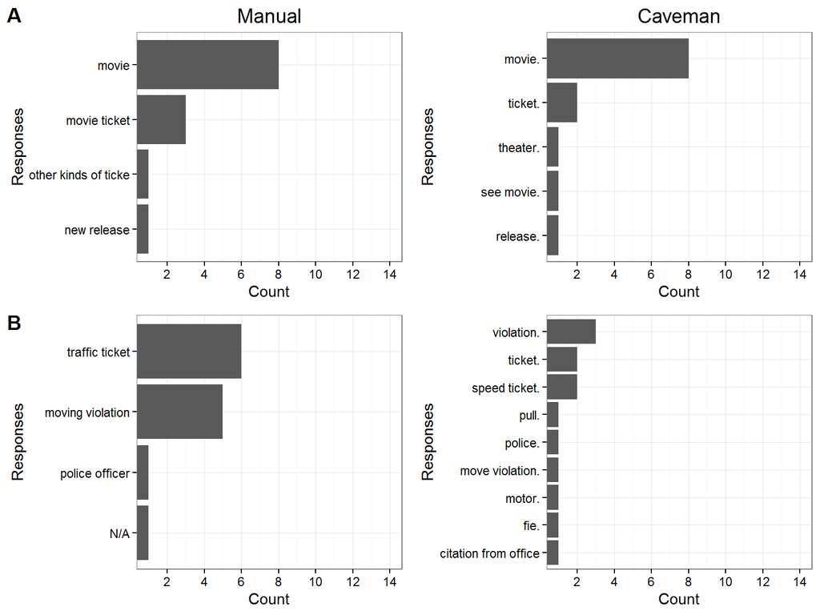

Target: “This is a long car ride.”

Context A: “X is driving across the country.”

Context B: “X is driving to work.”

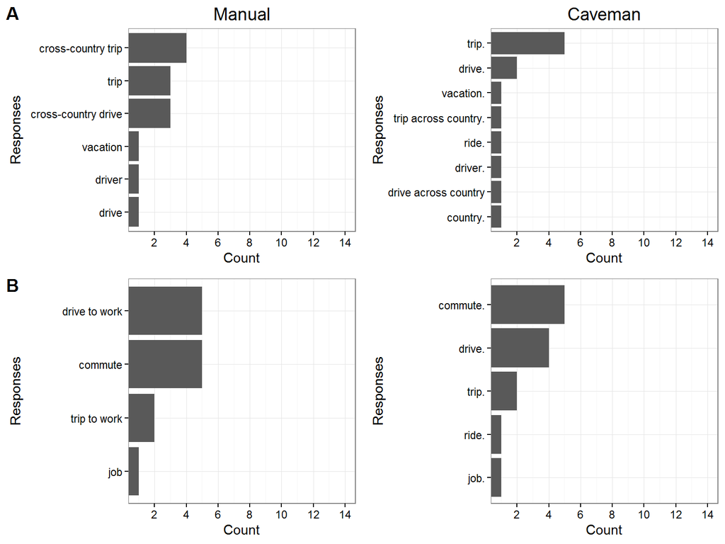

Target: “The office is open late.”

Context A: “X is making a doctor’s appointment.”

Context B: “X works at a call center.”

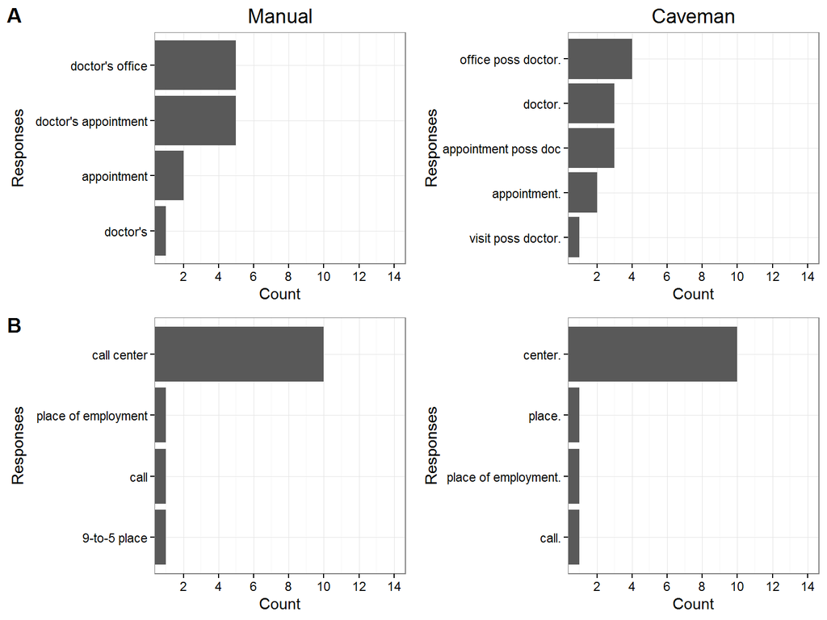

Target: “X is tall.”

Context A: “X is 4 years old.”

Context B: “X is 26 years old.”

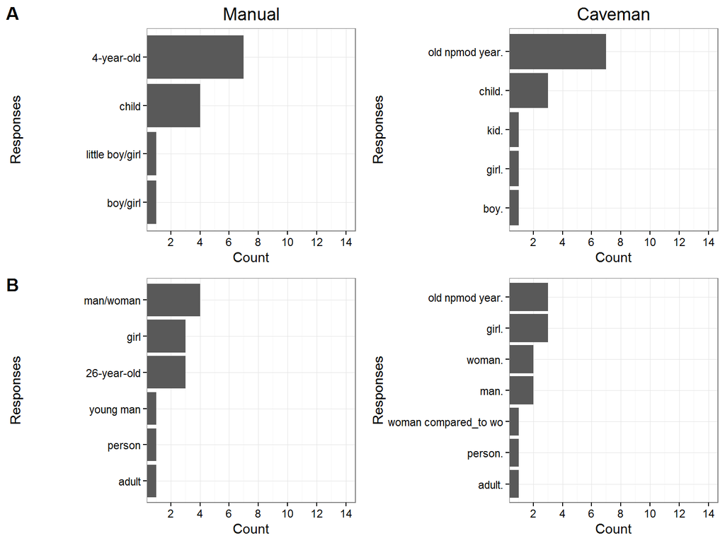

Target: “X is short.”

Context A: “X is a greyhound.”

Context B: “X is a professional basketball player.”

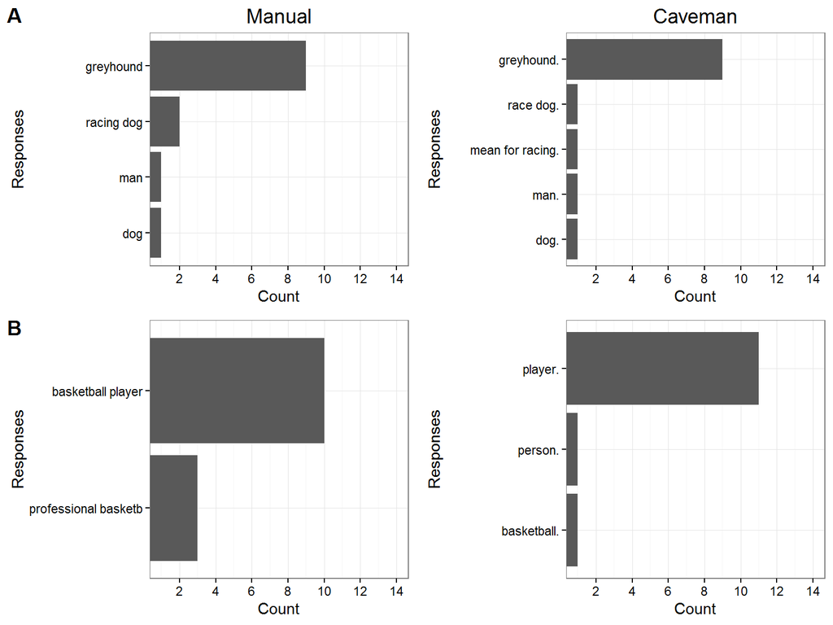

Target: “X is heavy.”

Context A: “X is a person.”

Context B: “X is a dancer.”

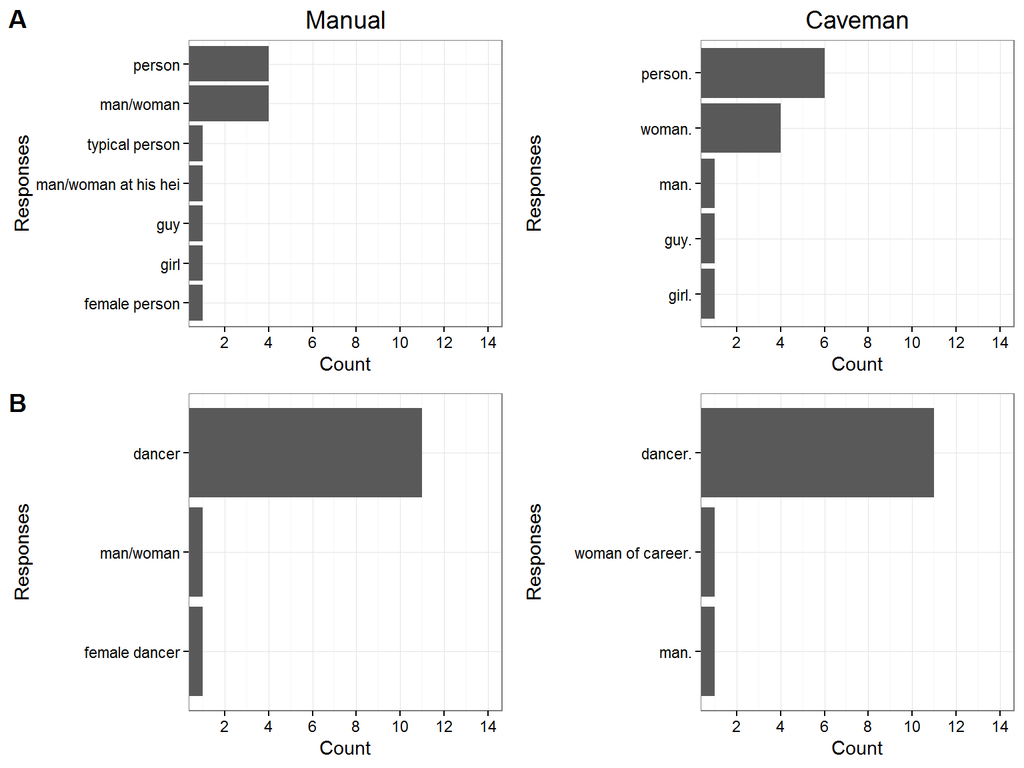

## “relative to” Condition

Target: “The coffee is hot.”

Context A: “X is a regular at the coffee shop and buys a cup of coffee.”

Context B: “X takes a sip of their friend’s coffee before returning back to their tea.”

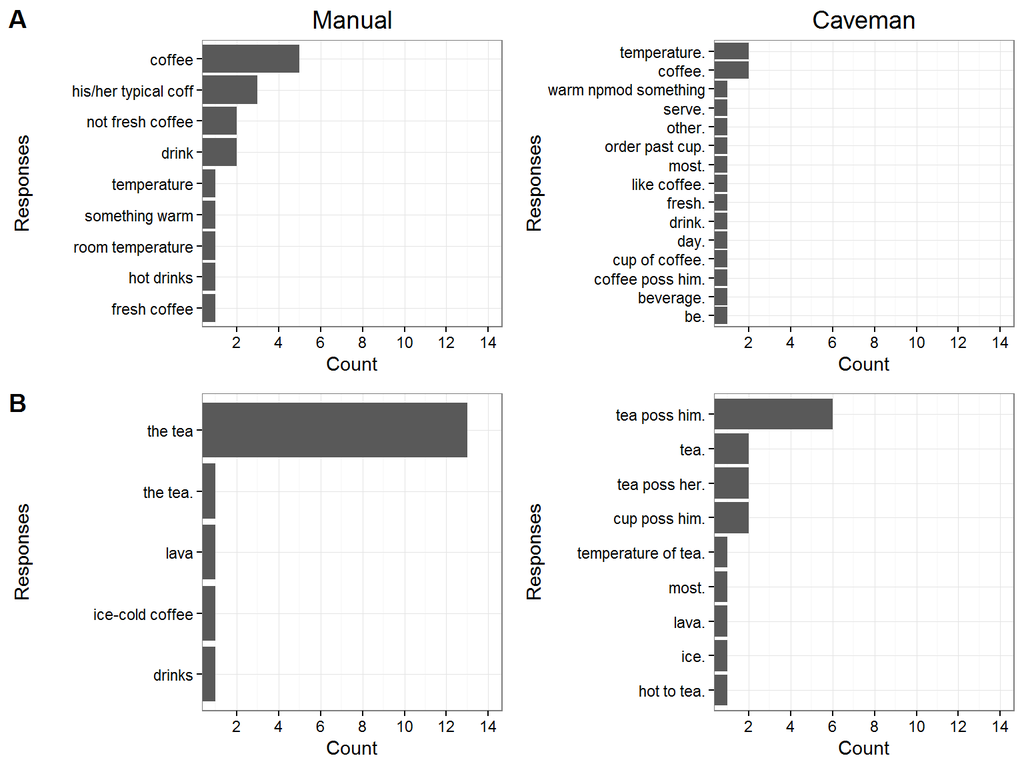

Target: “The weather is cold.”

Context A: “X just flew into New York from Florida.”

Context B: “X was raised in Russia.”

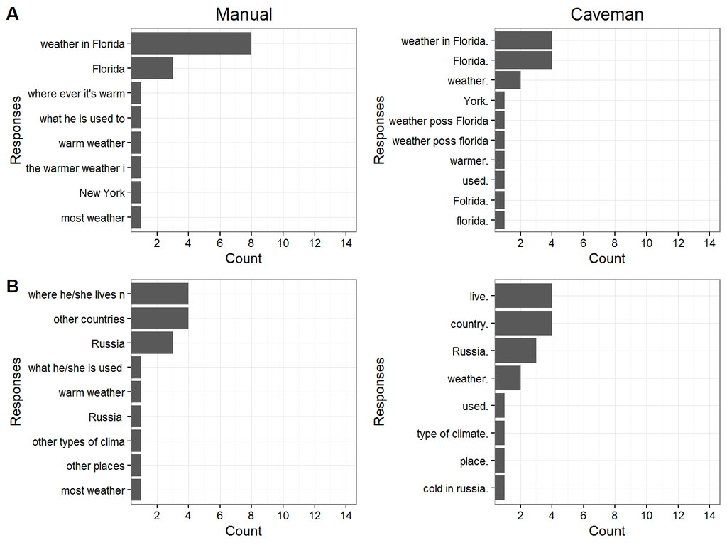

Target: “The necklace is expensive.”

Context A: “X is browsing at a jewelry store and stops to look at a necklace.”

Context B: " Xis buying a diamond necklace."

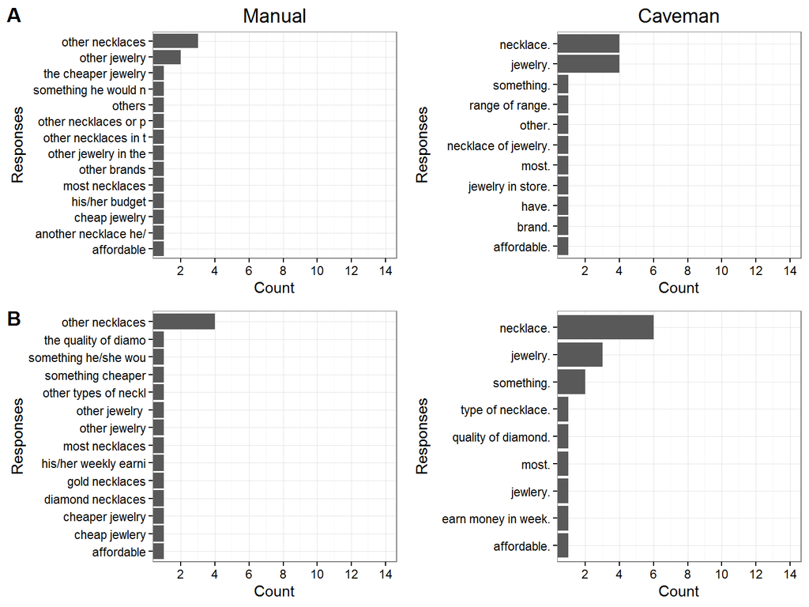

Target: “The ticket is cheap.”

Context A: “X is buying a movie ticket.”

Context B: “X got pulled over by a police officer.”

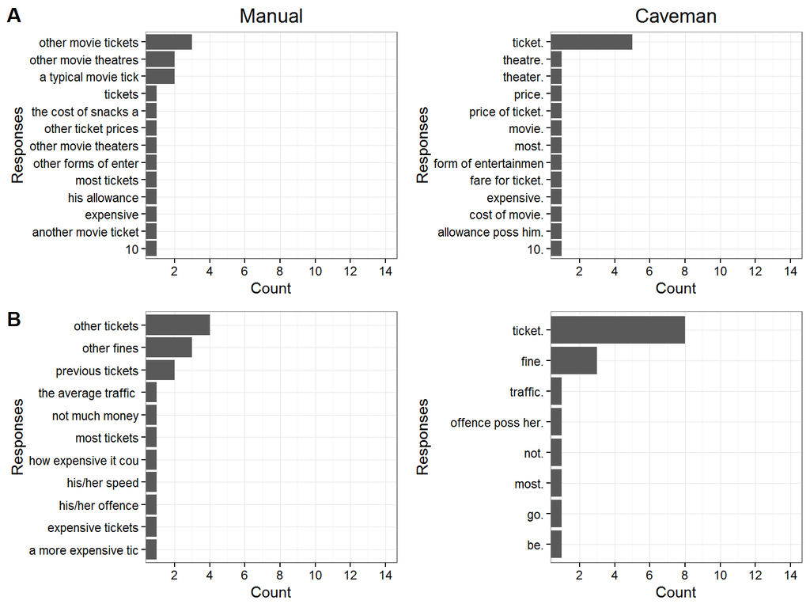

Target: “This is a long car ride.”

Context A: “X is driving across the country.”

Context B: “X is driving to work.”

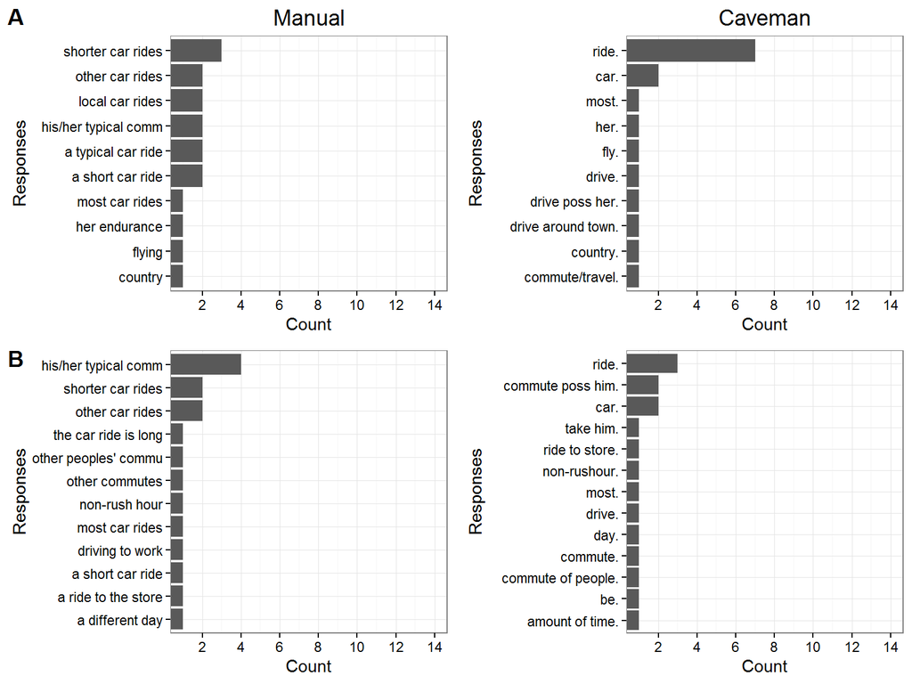

Target: “The office is open late.”

Context A: “X is making a doctor’s appointment.”

Context B: “X works at a call center.”

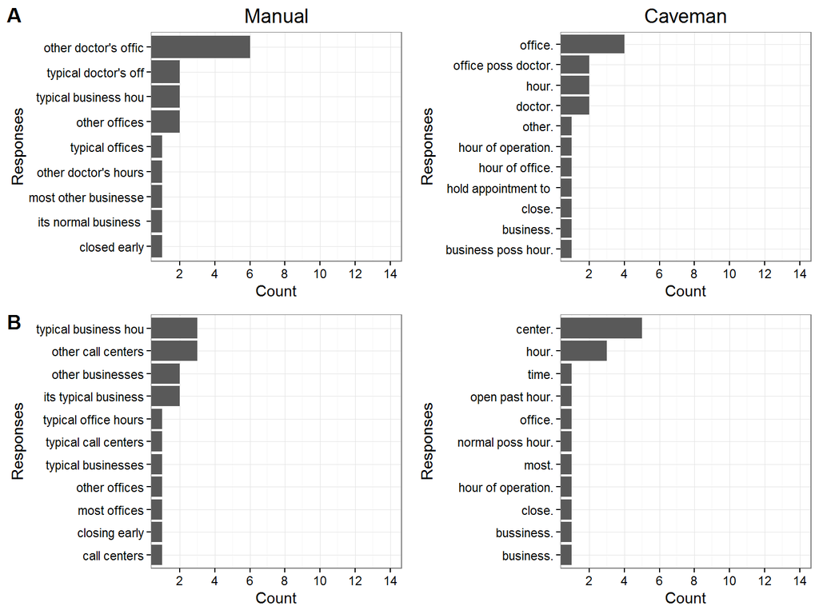

Target: “X is tall.”

Context A: “X is 4 years old.”

Context B: “X is 26 years old.”

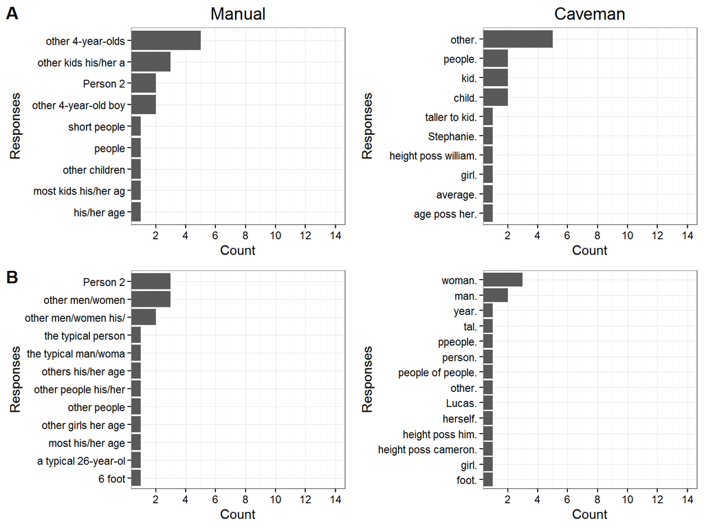

Target: “X is short.”

Context A: “X is a greyhound.”

Context B: “X is a professional basketball player.”

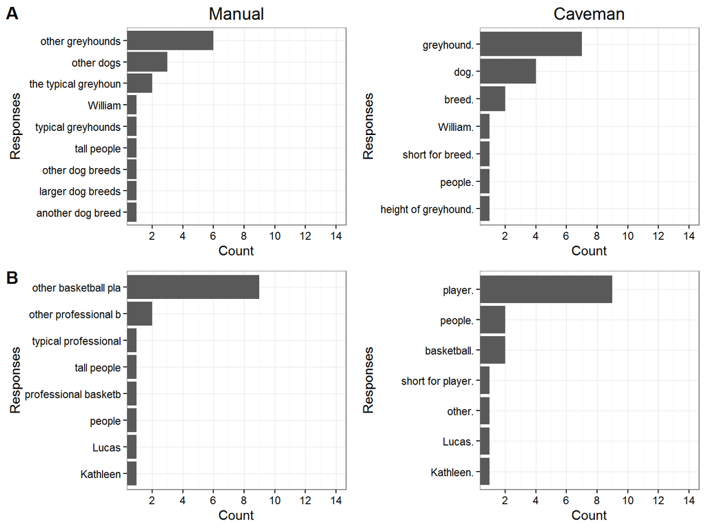

Target: “X is heavy.”

Context A: “X is a person.”

Context B: “X is a dancer.”

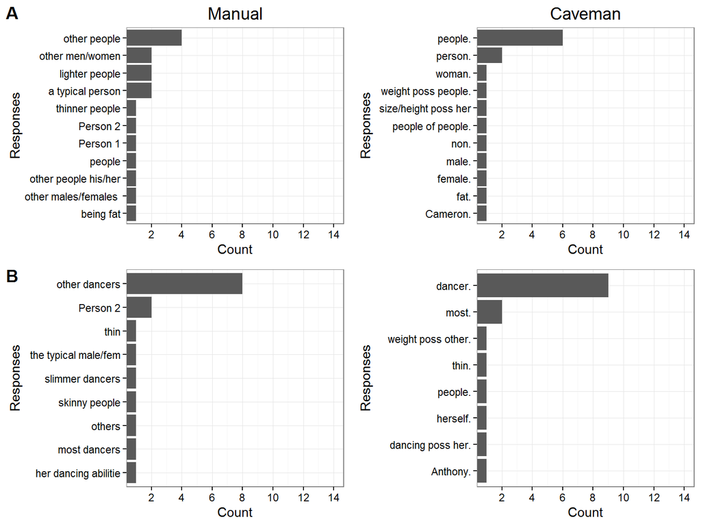

# Analysis

## “relative to” Condition

In general, most of the pairs in this condition experienced too much variability in responses. More of this will be touched on in the next section.

### Word usage

| other.count | typical.count | other.frequency | typical.frequency | responses.total |
| --- | --- | --- | --- | --- |
| 4 | 1 | 0.2353 | 0.05882 | 17 |
| 0 | 0 | 0 | 0 | 17 |
| 0 | 0 | 0 | 0 | 17 |
| 6 | 0 | 0.3529 | 0 | 17 |
| 10 | 0 | 0.5882 | 0 | 17 |
| 7 | 0 | 0.4118 | 0 | 17 |
| 8 | 0 | 0.4706 | 0 | 17 |
| 7 | 0 | 0.4118 | 0 | 17 |
| 2 | 1 | 0.1176 | 0.05882 | 17 |
| 3 | 1 | 0.1765 | 0.05882 | 17 |
| 10 | 1 | 0.5882 | 0.05882 | 17 |
| 6 | 2 | 0.3529 | 0.1176 | 17 |
| 10 | 0 | 0.5882 | 0 | 17 |
| 9 | 0 | 0.5294 | 0 | 17 |
| 10 | 0 | 0.5882 | 0 | 17 |
| 10 | 0 | 0.5882 | 0 | 17 |
| 9 | 0 | 0.5294 | 0 | 17 |
| 9 | 1 | 0.5294 | 0.05882 | 17 |

Table 1: Word frequency data from the “relative to” condition

The columns of the table correspond to:

- other.count: the number of times “other” occurred
- typical.count: the number of times the word “typical” occurred
- other.frequency: the frequency that the word “other” occurred (other.count / responses.total)
- typical.frequency: the frequency that the word “typical” occurred (typical.count / responses.total)

# Discussion

Looking at the data above, a stark difference between the conditions is the variability in responses: the “relative to” condition elicted far more unique responses than the “for a” condition. Also, the “relative to” condition elicited noun phrases, such as “other 4-year-olds,” rather than nouns, such as “4-year-olds,” as in the “for a” condition.

To tackle variability in future experiments, we plan to look at how participant responses are encoded. Should the phrases “doctor’s appointment” and “doctor’s office” be encoded as similar or different responses? Hand-encoding responses can lead to large variations in results, leading to data that is not reproducible. We seek to apply a formal tool for encoding responses in future experiments.

To best elicit the comparison class in our experiments, we have decided to update our “relative to” condition with a “relative to a” condition. Once we improve our experiment design and obtain these elicited classes, we can then measure participants’ background knowledge and interpretations using these contextual manipulations, incorporate it with the adjectives model in [1], and see if the knowledge from the classes we measured makes the right predictions for interpreting gradable adjectives.

# References

Bale, Alan Clinton. 2011. “Scales and Comparison Classes.” *Natural Language Semantics* 19 (2). Springer: 169–90.

Ebeling, Karen S, and Susan A Gelman. 1994. “Children’s Use of Context in Interpreting ‘Big’ and ‘Little’.” *Child Development* 65 (4). Wiley Online Library: 1178–92.

Keil, F.C. n.d. *Semantic and Conceptual Development: An Ontological Perspective*. Cognitive Science Series. Harvard University Press.

Lassiter, Daniel, and Noah D Goodman. 2013. “Context, Scale Structure, and Statistics in the Interpretation of Positive-Form Adjectives.” In *Semantics and Linguistic Theory*, 23:587–610.